```python
import numpy as np
import pandas as pd
import matplotlib
import matplotlib.pyplot as plt
import seaborn as sns
import scipy.stats as st
import statsmodels.stats.proportion as sp
```

# Nomor 1

```python
df_train = pd.read_csv(r'F:\COURSE\RAKAMIN\WEEK 7\train.csv')
df_train
```

|  | Id | MSSubClass | MSZoning | LotFrontage | LotArea | Street | Alley | LotShape | LandContour | Utilities | ... | PoolArea | PoolQC | Fence | MiscFeature | MiscVal | MoSold | YrSold | SaleType | SaleCondition | SalePrice |
| --- | --- | --- | --- | --- | --- | --- | --- | --- | --- | --- | --- | --- | --- | --- | --- | --- | --- | --- | --- | --- | --- |
| 0 | 1 | 60 | RL | 65.0 | 8450 | Pave | NaN | Reg | Lvl | AllPub | ... | 0 | NaN | NaN | NaN | 0 | 2 | 2008 | WD | Normal | 208500 |
| 1 | 2 | 20 | RL | 80.0 | 9600 | Pave | NaN | Reg | Lvl | AllPub | ... | 0 | NaN | NaN | NaN | 0 | 5 | 2007 | WD | Normal | 181500 |
| 2 | 3 | 60 | RL | 68.0 | 11250 | Pave | NaN | IR1 | Lvl | AllPub | ... | 0 | NaN | NaN | NaN | 0 | 9 | 2008 | WD | Normal | 223500 |
| 3 | 4 | 70 | RL | 60.0 | 9550 | Pave | NaN | IR1 | Lvl | AllPub | ... | 0 | NaN | NaN | NaN | 0 | 2 | 2006 | WD | Abnorml | 140000 |
| 4 | 5 | 60 | RL | 84.0 | 14260 | Pave | NaN | IR1 | Lvl | AllPub | ... | 0 | NaN | NaN | NaN | 0 | 12 | 2008 | WD | Normal | 250000 |
| ... | ... | ... | ... | ... | ... | ... | ... | ... | ... | ... | ... | ... | ... | ... | ... | ... | ... | ... | ... | ... | ... |
| 1455 | 1456 | 60 | RL | 62.0 | 7917 | Pave | NaN | Reg | Lvl | AllPub | ... | 0 | NaN | NaN | NaN | 0 | 8 | 2007 | WD | Normal | 175000 |
| 1456 | 1457 | 20 | RL | 85.0 | 13175 | Pave | NaN | Reg | Lvl | AllPub | ... | 0 | NaN | MnPrv | NaN | 0 | 2 | 2010 | WD | Normal | 210000 |
| 1457 | 1458 | 70 | RL | 66.0 | 9042 | Pave | NaN | Reg | Lvl | AllPub | ... | 0 | NaN | GdPrv | Shed | 2500 | 5 | 2010 | WD | Normal | 266500 |
| 1458 | 1459 | 20 | RL | 68.0 | 9717 | Pave | NaN | Reg | Lvl | AllPub | ... | 0 | NaN | NaN | NaN | 0 | 4 | 2010 | WD | Normal | 142125 |
| 1459 | 1460 | 20 | RL | 75.0 | 9937 | Pave | NaN | Reg | Lvl | AllPub | ... | 0 | NaN | NaN | NaN | 0 | 6 | 2008 | WD | Normal | 147500 |

1460 rows × 81 columns

```python
sales = df_train['SalePrice'].describe()
sales
```

```
count      1460.000000
mean     180921.195890
std       79442.502883
min       34900.000000
25%      129975.000000
50%      163000.000000
75%      214000.000000
max      755000.000000
Name: SalePrice, dtype: float64
```

```python
#variance
sales.var()
```

```
56550646916.71679
```

```python
#iqr
(sales.quantile(0.75))-(sales.quantile(0.25))
```

```
120884.01975564324
```

```python
#stdv
sales.std()
```

```
237803.79920580913
```

Dataframe di atas menunjukkan nilai statistik pada kolom SalePrice.Kolom ini secara spesifik akan mengetahui harga atau nilai jual rumah.  
**count** menunjukkan bahwa terdapat 1.460 observasi atau total data yang diamati dalam dataset ini.  
**mean** menunjukkan semua nilai dalam data dibagi dengan jumlah total observasi.  
**std** menunjukkan simpangan baku, yang mengukur sebaran data dari rata-rata. Artinya, semakin besar nilai simpangan baku, semakin besar pula variabilitas data.  
**min** menunjukkan nilai terkecil dalam kolom ini.  
**25%** adalah Q1.  
**50%** adalah median atau Q2 yang juga berarti nilai tengah data yang sebelumnya telah diurutkan secara asc.  
**75%** merupakan Q3.  
**max** adalah nilai tertinggi dalam kolom ini.

# Nomor 2

```python
sales_pertahun = df_train.groupby('YrSold')['SalePrice'].describe()
sales_pertahun
```

| YrSold | count | mean | std | min | 25% | 50% | 75% | max |
| --- | --- | --- | --- | --- | --- | --- | --- | --- |
| 2006 | 314.0 | 182549.458599 | 79426.838855 | 35311.0 | 131375.0 | 163995.0 | 218782.5 | 625000.0 |
| 2007 | 329.0 | 186063.151976 | 85768.171410 | 39300.0 | 129900.0 | 167000.0 | 219500.0 | 755000.0 |
| 2008 | 304.0 | 177360.838816 | 69735.610685 | 40000.0 | 131250.0 | 164000.0 | 207000.0 | 446261.0 |
| 2009 | 338.0 | 179432.103550 | 80879.237311 | 34900.0 | 125250.0 | 162000.0 | 212750.0 | 582933.0 |
| 2010 | 175.0 | 177393.674286 | 80451.280085 | 55000.0 | 128100.0 | 155000.0 | 213250.0 | 611657.0 |

# Nomor 3

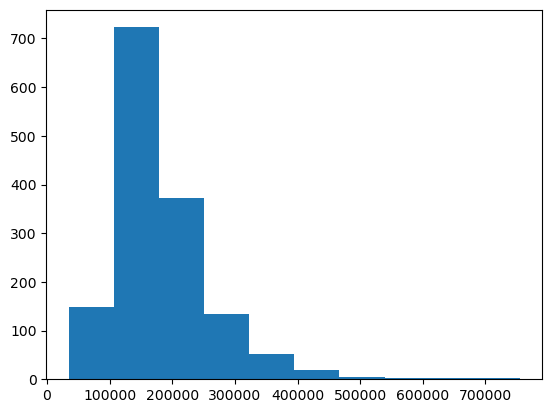

```python
plt.hist(df_train['SalePrice'])
plt.figure(figsize = (10,7))
plt.show()
```

Berdasarkan histogram di atas, diketahui bahwa sebaran data terjadi secara Positively Skewed.  
Hal tersebut terjadi karena nilai mean lebih besar daripada mediannya.

# Nomor 4

```python
df_train
```

|  | Id | MSSubClass | MSZoning | LotFrontage | LotArea | Street | Alley | LotShape | LandContour | Utilities | ... | PoolArea | PoolQC | Fence | MiscFeature | MiscVal | MoSold | YrSold | SaleType | SaleCondition | SalePrice |
| --- | --- | --- | --- | --- | --- | --- | --- | --- | --- | --- | --- | --- | --- | --- | --- | --- | --- | --- | --- | --- | --- |
| 0 | 1 | 60 | RL | 65.0 | 8450 | Pave | NaN | Reg | Lvl | AllPub | ... | 0 | NaN | NaN | NaN | 0 | 2 | 2008 | WD | Normal | 208500 |
| 1 | 2 | 20 | RL | 80.0 | 9600 | Pave | NaN | Reg | Lvl | AllPub | ... | 0 | NaN | NaN | NaN | 0 | 5 | 2007 | WD | Normal | 181500 |
| 2 | 3 | 60 | RL | 68.0 | 11250 | Pave | NaN | IR1 | Lvl | AllPub | ... | 0 | NaN | NaN | NaN | 0 | 9 | 2008 | WD | Normal | 223500 |
| 3 | 4 | 70 | RL | 60.0 | 9550 | Pave | NaN | IR1 | Lvl | AllPub | ... | 0 | NaN | NaN | NaN | 0 | 2 | 2006 | WD | Abnorml | 140000 |
| 4 | 5 | 60 | RL | 84.0 | 14260 | Pave | NaN | IR1 | Lvl | AllPub | ... | 0 | NaN | NaN | NaN | 0 | 12 | 2008 | WD | Normal | 250000 |
| ... | ... | ... | ... | ... | ... | ... | ... | ... | ... | ... | ... | ... | ... | ... | ... | ... | ... | ... | ... | ... | ... |
| 1455 | 1456 | 60 | RL | 62.0 | 7917 | Pave | NaN | Reg | Lvl | AllPub | ... | 0 | NaN | NaN | NaN | 0 | 8 | 2007 | WD | Normal | 175000 |
| 1456 | 1457 | 20 | RL | 85.0 | 13175 | Pave | NaN | Reg | Lvl | AllPub | ... | 0 | NaN | MnPrv | NaN | 0 | 2 | 2010 | WD | Normal | 210000 |
| 1457 | 1458 | 70 | RL | 66.0 | 9042 | Pave | NaN | Reg | Lvl | AllPub | ... | 0 | NaN | GdPrv | Shed | 2500 | 5 | 2010 | WD | Normal | 266500 |
| 1458 | 1459 | 20 | RL | 68.0 | 9717 | Pave | NaN | Reg | Lvl | AllPub | ... | 0 | NaN | NaN | NaN | 0 | 4 | 2010 | WD | Normal | 142125 |
| 1459 | 1460 | 20 | RL | 75.0 | 9937 | Pave | NaN | Reg | Lvl | AllPub | ... | 0 | NaN | NaN | NaN | 0 | 6 | 2008 | WD | Normal | 147500 |

1460 rows × 81 columns

```python
df_train['YrSold'].value_counts()
```

```
2009    338
2007    329
2006    314
2008    304
2010    175
Name: YrSold, dtype: int64
```

H0 : Harga rumah tidak mengalami kenaikan setiap tahunnya  
H1 : harga rumah mengalami kenaikan setiap tahunnya

```python
df_train.groupby('YrSold')['SalePrice'].agg('mean')
```

```
YrSold
2006    182549.458599
2007    186063.151976
2008    177360.838816
2009    179432.103550
2010    177393.674286
Name: SalePrice, dtype: float64
```

```python
tahun_2006 = df_train[df_train['YrSold']==2006]
tahun_2007 = df_train[df_train['YrSold']==2007]
tahun_2008 = df_train[df_train['YrSold']==2008]
tahun_2009 = df_train[df_train['YrSold']==2009]
tahun_2010 = df_train[df_train['YrSold']==2010]
```

```python
print('rata-rata harga rumah pada tahun 2006 adalah',tahun_2006['SalePrice'].mean())
print('rata-rata harga rumah pada tahun 2007 adalah',tahun_2007['SalePrice'].mean())
print('rata-rata harga rumah pada tahun 2008 adalah',tahun_2008['SalePrice'].mean())
print('rata-rata harga rumah pada tahun 2009 adalah',tahun_2009['SalePrice'].mean())
print('rata-rata harga rumah pada tahun 2010 adalah',tahun_2010['SalePrice'].mean())
```

```
rata-rata harga rumah pada tahun 2006 adalah 182549.4585987261
rata-rata harga rumah pada tahun 2007 adalah 186063.1519756839
rata-rata harga rumah pada tahun 2008 adalah 177360.83881578947
rata-rata harga rumah pada tahun 2009 adalah 179432.10355029587
rata-rata harga rumah pada tahun 2010 adalah 177393.67428571428
```

```python
anova_result = st.f_oneway(tahun_2006['SalePrice'],
                           tahun_2007['SalePrice'],
                           tahun_2008['SalePrice'],
                           tahun_2009['SalePrice'],
                           tahun_2010['SalePrice'])
anova_result
```

```
F_onewayResult(statistic=0.6455252211679311, pvalue=0.6300887663573457)
```

```python
pvalue = anova_result.pvalue
print('p-value = ',pvalue)
```

```
p-value =  0.6300887663573457
```

```python
if pvalue >=0.05:
    print('terima h0 karena rata-rata harga rumah tidak mengalami kenaikan setiap tahunnya, atau kenaikan harga rumah tidak signifikan')
else:
    print('terima h1 karena rata-rata harga rumah mengalami kenaikan setiap tahunnya, atau kenaikan harga rumah signifikan.')
```

```
terima h0 karena rata-rata harga rumah tidak mengalami kenaikan setiap tahunnya, atau kenaikan harga rumah tidak signifikan
```

Penggunaan pvalue dalam hal ini akan memvalidasi hipotesis terhadap data yang diamati.  
P value berguna untuk melihat probabilitas H0 diterima atau ditolak dengan membandingkan nilai pvalue dengan alpha (sebesar 0.05).  
Sementara itu, anova digunakan karena pada kasus ini kita diminta untuk membandingkan rata-rata antara beberapa populasi

# Nomor 5

Nama experimen = A/B Testing  
Definisi Hipotesis = Jumlah campaign efektif dalam meningkatkan keinginan pengguna untuk membuka akun deposit  
Partisipan = Nasabah yang akan membuka akun deposit  
Variabel yang akan diuji = Jumlah campaign  
Metrics = Conversion rate. Dalam hal ini akan mengukur kuantitas nasabah yang melihat campaign dan akhirnya membuka akun deposit.  
Metrics ini akan mampu memberikan gambaran langsung tentang dampak kampanye terhadap konversi pengguna.

```python
df_bank = pd.read_csv(r'F:\COURSE\RAKAMIN\WEEK 7\bank-full.csv',sep=";")
df_bank
```

|  | age | job | marital | education | default | balance | housing | loan | contact | day | month | duration | campaign | pdays | previous | poutcome | y |
| --- | --- | --- | --- | --- | --- | --- | --- | --- | --- | --- | --- | --- | --- | --- | --- | --- | --- |
| 0 | 58 | management | married | tertiary | no | 2143 | yes | no | unknown | 5 | may | 261 | 1 | -1 | 0 | unknown | no |
| 1 | 44 | technician | single | secondary | no | 29 | yes | no | unknown | 5 | may | 151 | 1 | -1 | 0 | unknown | no |
| 2 | 33 | entrepreneur | married | secondary | no | 2 | yes | yes | unknown | 5 | may | 76 | 1 | -1 | 0 | unknown | no |
| 3 | 47 | blue-collar | married | unknown | no | 1506 | yes | no | unknown | 5 | may | 92 | 1 | -1 | 0 | unknown | no |
| 4 | 33 | unknown | single | unknown | no | 1 | no | no | unknown | 5 | may | 198 | 1 | -1 | 0 | unknown | no |
| ... | ... | ... | ... | ... | ... | ... | ... | ... | ... | ... | ... | ... | ... | ... | ... | ... | ... |
| 45206 | 51 | technician | married | tertiary | no | 825 | no | no | cellular | 17 | nov | 977 | 3 | -1 | 0 | unknown | yes |
| 45207 | 71 | retired | divorced | primary | no | 1729 | no | no | cellular | 17 | nov | 456 | 2 | -1 | 0 | unknown | yes |
| 45208 | 72 | retired | married | secondary | no | 5715 | no | no | cellular | 17 | nov | 1127 | 5 | 184 | 3 | success | yes |
| 45209 | 57 | blue-collar | married | secondary | no | 668 | no | no | telephone | 17 | nov | 508 | 4 | -1 | 0 | unknown | no |
| 45210 | 37 | entrepreneur | married | secondary | no | 2971 | no | no | cellular | 17 | nov | 361 | 2 | 188 | 11 | other | no |

45211 rows × 17 columns

**T-test**

H0 = Jumlah campaign tidak memiliki dampak yang signifikan terhadap keinginan pengguna untuk membuka akun deposit  
H1 = Jumlah campaign memiliki dampak yang signifikan terhadap keinginan pengguna untuk membuka akun deposit

```python
campaign = df_bank[df_bank['y']=='yes']
not_campaign = df_bank[df_bank['y']!='yes']
```

```python
campaign.head()
```

[output not shown]

```python
not_campaign.head()
```

|  | age | job | marital | education | default | balance | housing | loan | contact | day | month | duration | campaign | pdays | previous | poutcome | y |
| --- | --- | --- | --- | --- | --- | --- | --- | --- | --- | --- | --- | --- | --- | --- | --- | --- | --- |
| 0 | 58 | management | married | tertiary | no | 2143 | yes | no | unknown | 5 | may | 261 | 1 | -1 | 0 | unknown | no |
| 1 | 44 | technician | single | secondary | no | 29 | yes | no | unknown | 5 | may | 151 | 1 | -1 | 0 | unknown | no |
| 2 | 33 | entrepreneur | married | secondary | no | 2 | yes | yes | unknown | 5 | may | 76 | 1 | -1 | 0 | unknown | no |
| 3 | 47 | blue-collar | married | unknown | no | 1506 | yes | no | unknown | 5 | may | 92 | 1 | -1 | 0 | unknown | no |
| 4 | 33 | unknown | single | unknown | no | 1 | no | no | unknown | 5 | may | 198 | 1 | -1 | 0 | unknown | no |

```python
campaign['campaign'].mean()
```

```
2.1410474569861977
```

```python
not_campaign['campaign'].mean()
```

```
2.8463503832473322
```

```python
ttest = st.ttest_ind(a = campaign['campaign'], b=not_campaign['campaign'])
ttest
```

```
Ttest_indResult(statistic=-15.599948860003783, pvalue=1.0123473642096295e-54)
```

```python
p_value = ttest.pvalue
p_value
```

```
1.0123473642096295e-54
```

```python
if p_value >= 0.05:
    print('Jumlah campaign tidak memiliki dampak yang signifikan terhadap keinginan pengguna untuk membuka akun deposit')
else:
    print('Jumlah campaign memiliki dampak yang signifikan terhadap keinginan pengguna untuk membuka akun deposit')
```

```
Jumlah campaign memiliki dampak yang signifikan terhadap keinginan pengguna untuk membuka akun deposit
```